# Chapitre 9

## Le futur se trace

Manœuvrer dans le digital avec les cartes de Wardley

Le futur se trace

Manœuvrer dans le digital avec les cartes de Wardley

Olivier Wulveryck

# Chapitre 9 : Lire la carte — Anticiper le mouvement et révéler l’inertie

## La carte ne décide pas, elle révèle

Au chapitre précédent, nous avons appris à construire une carte de Wardley. Nous avons suivi une méthode : identifier le repère, lister les composants, tracer les dépendances, positionner sur les axes. C’est la partie **méthodique** du cycle de vie d’une carte (une grammaire, une syntaxe, presque un algorithme).

Mais une fois le marqueur posé, la méthode s’arrête et la stratégie commence.

### Le cycle de vie d’une carte

Il existe deux temps distincts dans la vie d’une carte, et les confondre conduit à des erreurs fatales.

Le premier temps est celui de la conception. C’est un exercice structuré qui peut être enseigné, reproduit, délégué. Une équipe formée peut construire une carte en suivant les étapes que nous avons décrites. Ce temps-là accepte une certaine automatisation : des outils numériques peuvent aider à organiser les composants, calculer les positions, suggérer des liens.

Le second temps est celui de l’analyse. C’est ici que tout change. L’analyse d’une carte reste, et restera toujours, à la main des experts et des décideurs. C’est à l’humain d’assumer la responsabilité du choix, armé d’une meilleure vision.

C’est ici que beaucoup d’équipes commettent une erreur fatale : elles attendent de la carte qu’elle leur donne la réponse, comme une calculatrice donnerait le résultat d’une équation. Or, une carte de Wardley n’est pas un outil déterministe. Elle ne vous dira jamais « Faites X ». Elle vous dira « Voici le paysage, voici les forces, voici les dangers ».

Certains rêvent d’automatiser la stratégie. Ils imaginent un algorithme qui prendrait une carte en entrée et produirait un plan d’action en sortie. Ce rêve est vain — et dangereux. Une carte ne peut pas être « programmée » pour prendre des décisions automatiquement, car elle ne contient pas l’intuition, l’éthique, ou l’audace du stratège. Elle est là pour aligner les esprits et révéler le contexte, afin que *vous* puissiez prendre la décision difficile en toute conscience.

### Le test de la surprise : une bonne carte vous contredit

Comment savoir si votre carte est utile ? Il existe un test simple, presque infaillible.

Si, une fois terminée, votre carte confirme exactement tout ce que vous pensiez déjà savoir, si elle valide parfaitement votre plan initial sans soulever la moindre question inconfortable… alors c’est probablement une mauvaise carte. Ou pire : ce n’est pas une carte, c’est une illustration.

Nous avons tous l’habitude de créer des diagrammes pour *vendre* une idée déjà arrêtée. Nous utilisons le visuel pour justifier une décision prise en amont. C’est ce qu’on appelle le « biais de confirmation » transformé en diaporama (PowerPoint).

Une véritable carte de Wardley fonctionne à l’inverse. **Elle doit vous surprendre.** Vous scrutez le résultat et soudain, une dissonance apparaît. Ce composant que vous jugiez critique ? La carte montre qu’il est invisible pour le client final. Cette maîtrise technique dont vous étiez fiers ? Elle repose sur une technologie en phase de Genèse, terriblement instable. Ces investissements massifs que vous avez engagés ? Tout le reste de la chaîne glisse vers la commodité, rendant vos efforts obsolètes. Et ce composant secondaire auquel personne ne prêtait attention ? Il se révèle être au centre de toutes les dépendances (un point de passage obligé que vous aviez négligé).

C’est dans ces moments de dissonance, quand la représentation visuelle heurte votre intuition ou vos croyances, que la valeur stratégique émerge. Si la carte ne vous surprend pas, c’est que vous n’avez pas regardé assez près.

### La carte raconte l’histoire (et non l’inverse)

Dans l’approche traditionnelle, le dirigeant construit une histoire (le récit, ou *storytelling*), puis demande à ses équipes de produire des graphiques pour l’illustrer. L’histoire précède le visuel. Le récit est écrit avant l’observation.

Avec la cartographie, nous inversons le flux : nous observons d’abord le terrain en traçant la carte, puis nous identifions les mouvements et les blocages qui s’y dessinent, et c’est de cette observation (et non d’un récit préconçu) qu’émerge l’histoire stratégique.

**C’est la carte qui doit raconter l’histoire.** Si vous essayez de tordre la carte pour qu’elle corresponde à votre narratif politique ou budgétaire, vous brisez le thermomètre pour nier la fièvre.

L’analyse de la carte n’est donc pas un exercice de validation, c’est un exercice d’humilité. Il faut accepter de laisser le territoire dicter ses lois, pour ensuite décider, en tant que décideur éclairé, quel chemin emprunter.

Cette inversion est inconfortable. Elle demande de renoncer au confort de la certitude précoce. Mais elle est la condition sine qua non d’une stratégie ancrée dans le réel.

### L’outil d’alignement vs l’outil déterministe

Il existe des pièges à éviter. N’imposez jamais la cartographie comme outil obligatoire (elle fonctionne par adhésion volontaire, pas par décret). N’enseignez pas la théorie avant de laisser les équipes pratiquer : la séquence naturelle n’est pas « apprendre la théorie → cartographier », mais « ressentir le besoin d’alignement → cartographier ensemble → comprendre la théorie en pratiquant ». Ne cartographiez pas sans accord préalable sur le problème à résoudre, et n’utilisez pas cet outil pour des décisions sans implication stratégique. Quand l’équipe ne perçoit pas le besoin de s’aligner sur une vision commune, forcer la pratique produit des cartes fictives (de simples illustrations de décisions déjà prises, des diaporamas déguisés).

Votre responsabilité demeure entière : interpréter ce que la carte révèle, assumer les décisions qui en découlent, et agir malgré l’incertitude résiduelle. La carte est un **outil d’alignement**, pas un outil de prédiction. Elle ne vous dit pas ce qui va arriver. Elle vous prépare à réagir intelligemment quand les choses arriveront.

## Les rails et les cygnes : réconcilier Wardley et Taleb

Au **chapitre 5**, nous avons découvert la Loi Universelle de l’Évolution : tout composant technologique utile suit une trajectoire prévisible vers la commodité. Cette vision rassurante (des rails sur lesquels glisse l’innovation) semble contredire une autre voix, celle de Nassim Nicholas Taleb.

Taleb est un essayiste et statisticien libano-américain, ancien trader d’options devenu philosophe de l’incertitude. Son ouvrage *Le Cygne Noir* (2007)[^1] a profondément marqué la pensée contemporaine sur le risque et la prévision. Le *Sunday Times* l’a classé parmi les douze livres les plus influents depuis la Seconde Guerre mondiale[^2], et ses concepts (le Cygne Noir, l’antifragilité[^3], le Médiocristan et l’Extremistan) sont devenus des références incontournables pour quiconque réfléchit à la stratégie dans un monde incertain.

Là où Wardley nous dit que la direction est prévisible, Taleb nous rappelle que le monde est fondamentalement imprévisible. Ces deux visions s’opposent-elles ? Ou peut-on les articuler ?

### Direction prévisible, rythme imprévisible

L’évolution vers la commodité est une **gravité économique** (inévitable mais non déterministe). La trajectoire est prévisible : tout ce qui est utile glisse vers la droite de la carte. Mais **inévitable ne signifie pas programmé**. Nous savons *où* va une technologie utile, pas *quand* elle y arrivera. Les « rails » définissent la direction, mais le train peut ralentir, accélérer, ou dérailler.

De plus, **un composant ne se téléporte jamais d’une phase à l’autre**. L’évolution ne fait pas de sauts. Chaque phase apporte les conditions nécessaires à la suivante (la Genèse explore, le Sur-mesure reproduit, le Produit industrialise, la Commodité optimise). Si vous observez un « saut » apparent, c’est généralement qu’un nouveau composant a remplacé l’ancien.

L’exemple de la photographie l’illustre : la pellicule argentique n’a pas « sauté » vers la commodité numérique. La photographie numérique a créé une *nouvelle* courbe d’évolution qui a rendu l’ancienne obsolète. Ce n’est pas une accélération — c’est un nouveau jeu.

### Extremistan et Médiocristan sur la carte

Taleb distingue deux mondes statistiques fondamentalement différents[^4], qui se superposent remarquablement à l’axe d’évolution de la carte.

**À gauche de la carte (en Genèse et Sur-mesure) règne l’Extremistan.** C’est le monde de l’incertitude radicale, où les lois de puissance dominent et où les Cygnes Noirs sont possibles. Une idée sur mille réussit, mais celle qui réussit rafle tout (le gagnant rafle tout, *winner takes all*). Impossible de prédire le retour sur investissement (ROI) ou la durée d’un projet. C’est le royaume du capital-risque (*Venture Capital*), de l’exploration, et des paris asymétriques.

**À droite de la carte (en Produit et Commodité) s’étend le Médiocristan.** Ici, la distribution normale (gaussienne) s’applique. Les événements sont prévisibles, l’écart-type est faible, les surprises sont rares. Six Sigma[^5] fonctionne. L’optimisation est possible. Les prévisions financières ont du sens.

|  | Extremistan (gauche) | Médiocristan (droite) |
| --- | --- | --- |
| **Phases** | Genèse, Sur-mesure | Produit, Commodité |
| **Distribution** | Lois de puissance | Distribution normale |
| **Prévisibilité** | Impossible | Élevée |
| **Cygnes Noirs** | Possibles | Rares |
| **Méthodes adaptées** | Exploration, produit minimum viable (MVP) | Six Sigma, Lean (production allégée) |

Cette superposition révèle une **erreur fatale** : utiliser des outils du Médiocristan (planification détaillée, prévisions précises) pour gérer des composants en Extremistan (innovation radicale). Un responsable qui applique des méthodes de gestion de risque classiques à un projet en phase de Genèse verra son modèle exploser au premier imprévu.

### Le Cygne Noir rebat les cartes

**Le Cygne Noir ne change pas les règles du jeu. Il change le jeu lui-même.**

Un événement imprévisible à fort impact ne va pas « accélérer » vos composants sur leur trajectoire. Il bouleverse le jeu lui-même. Des composants peuvent mourir instantanément parce que la demande qui les portait disparaît. De nouveaux besoins surgissent, créant des chaînes de valeur inédites. Et la visibilité peut basculer brutalement (ce qui était invisible devient soudain critique, et inversement).

### Fil rouge : La start-up SaaS et le cloud souverain (suite du chapitre 8)

Reprenons l’exemple de la start-up française développant une application de gestion de projet en logiciel en tant que service (SaaS) que nous avons cartographié au **chapitre 8**. Ce cas illustre comment un événement extérieur peut remonter brutalement la visibilité d’un composant.

En 2020 : Le cloud computing était à quatre sauts du besoin utilisateur, un composant d’infrastructure invisible, choisi sur des critères purement techniques (performance, coût, fiabilité). La décision relevait du directeur technique (CTO). Budget : optimisation continue.

**La vague réglementaire : NIS2, Data Act, SecNumCloud (2022-2024)**

Plusieurs événements réglementaires et commerciaux convergent : la directive NIS2 impose des obligations de sécurité si strictes sur la chaîne de sous-traitance qu’elle pousse de fait vers un hébergement souverain[^6], le Data Act européen introduit des exigences strictes de portabilité pour faciliter le changement de fournisseur cloud[^7], les certifications SecNumCloud deviennent requises pour les marchés publics[^8], les grands comptes exigent un hébergement français, et les concurrents lancent des offres « 100% souverain ».

Est-ce un Cygne Noir au sens strict de Taleb ? Pas exactement. Un vrai Cygne Noir est un événement *totalement imprévisible*, à fort impact, et *rationalisé après coup*. Or, ces réglementations étaient annoncées, discutées, votées progressivement. Pour qui suivait les débats européens, rien de surprenant.

Mais voici la nuance essentielle : **ce qui compte stratégiquement, c’est moins la nature de l’événement que la capacité à anticiper ses conséquences sur votre chaîne de valeur**. Pour cette start-up, comme pour des milliers d’entreprises, l’impact sur leur activité était tout aussi imprévisible qu’un Cygne Noir. Elles n’avaient pas cartographié le chemin entre « réglementation européenne » et « choix de notre fournisseur cloud ». L’événement était prévisible ; ses implications sur leur carte ne l’étaient pas.

Après la vague : Le cloud passe de quatre sauts à un ou deux sauts. Il devient un critère de sélection commercial visible sur la page d’accueil, un risque de conformité réglementaire, et un différenciateur concurrentiel.

Ce que la carte a révélé :

Avant l’analyse de visibilité, l’équipe voyait le cloud comme un « détail technique ». La carte a forcé à tracer **tous** les chemins entre le repère et le composant Cloud. Comme illustré au chapitre 8, la carte révèle comment les nouveaux chemins de visibilité transforment la position stratégique du cloud.

Le chemin technique initial (Besoin utilisateur → Interface → API → Base de données → Cloud) plaçait le cloud à quatre sauts, invisible. Mais les nouveaux chemins créés par la réglementation (Besoin utilisateur → Conformité réglementaire → Cloud, ou Besoin utilisateur → Argumentaire commercial → Cloud) réduisent cette distance à deux sauts. La visibilité réelle devient celle du chemin le plus court : **deux sauts**. Le composant qui semblait invisible est devenu critique et visible.

Le contexte a changé la visibilité. La carte a révélé ce changement.

La carte ne prédit pas les ruptures. Mais elle vous prépare à les identifier rapidement et à comprendre leurs implications stratégiques. Au **chapitre 10**, nous verrons quelles manœuvres cette start-up a exécutées pour répondre à ce changement.

### Synthèse : naviguer avec la carte

La cartographie de Wardley et les travaux de Taleb se complètent plus qu’ils ne s’opposent. **Wardley nous dit que l’évolution vers la commodité est une gravité économique** (la direction est prévisible, les composants ne sautent pas de phases). **Taleb nous rappelle que le rythme reste imprévisible**, que des composants peuvent mourir, que de nouveaux jeux émergent, et que l’Extremistan résiste à la prédiction.

Pour l’Architecte du Mouvement, la carte donne la **direction probable**, pas la destination garantie. Et surtout, la sagesse stratégique consiste à savoir quand utiliser les rails et quand s’en écarter.

### La carte est éphémère

Une carte de Wardley n’est pas un document à maintenir indéfiniment. Elle est **éphémère** : elle vit le temps d’une prise de décision stratégique, puis elle meurt.

Imaginez que vous êtes face à un choix difficile : racheter un concurrent, migrer votre architecture vers le cloud, ou pivoter votre offre produit. Vous convoquez vos équipes, vous dessinez la carte ensemble, vous débattez pendant quelques heures, peut-être quelques jours. La carte sert de langage commun, de terrain de jeu pour explorer les scénarios. Une fois la décision prise (disons, après deux ou trois semaines de réflexion collective), la carte a rempli son rôle. Elle devient alors un artefact historique, un instantané du raisonnement qui a conduit à la décision.

Mais vous ne la « maintenez » pas comme vous maintenez un wiki d’entreprise ou un diagramme d’architecture. Vous ne passez pas tous les lundis matins à mettre à jour les positions des composants. Ce serait un gaspillage de temps et d’énergie mentale.

À la place, vous archivez cette carte avec la décision qu’elle a éclairée. Six mois plus tard, quand un collègue se demandera « pourquoi avons-nous fait ce choix ? », il pourra relire la carte et comprendre le contexte de l’époque. Elle devient un outil de communication *a posteriori*, une trace du raisonnement stratégique.

Et quand un nouveau problème émerge (une régulation qui bouleverse votre marché, un concurrent qui lance une offre disruptive, une fusion-acquisition qui redéfinit le périmètre), vous ne ressortez pas l’ancienne carte pour la « mettre à jour ». Vous en dessinez une nouvelle, adaptée au nouveau contexte, avec les nouvelles questions à résoudre.

Ne tombez pas dans le piège de la « maintenance de cartes ». Cartographiez quand vous en avez besoin. Archivez quand la décision est prise. Recommencez quand un nouveau besoin émerge. La carte est un outil de décision, pas un inventaire perpétuel.

## Les schémas climatiques : les forces qui poussent l’évolution

Comment identifier les forces qui poussent les composants vers la droite ? Comment anticiper le mouvement ?

Simon Wardley a identifié une série de **schémas climatiques** (*patterns*)[^9], des forces récurrentes qui s’exercent sur toute carte, indépendamment du contexte spécifique. Ces forces sont l’équivalent des courants marins pour le navigateur : on ne peut pas les arrêter, mais on peut les utiliser.

### Les forces d’évolution

L’offre et la demande ne sont pas les seules forces en jeu. Au-delà de la co-évolution décrite au chapitre 5, plusieurs dynamiques accélèrent ou freinent le mouvement. Certaines forces agissent comme une gravité qui tire les composants vers la droite. L’effet de réseau joue un rôle majeur : plus un composant est utilisé, plus il devient attractif, et des standards émergent puis s’imposent. Les économies d’échelle amplifient ce mouvement (la production en volume réduit les coûts, rendant le composant accessible à un public toujours plus large). L’open source agit comme un catalyseur en accélérant la diffusion des pratiques et la standardisation. Enfin, la réglementation pro-concurrence peut forcer l’ouverture de marchés captifs et libérer l’évolution.

Mais d’autres forces résistent, créant une friction qui ralentit la glissade. L’inertie organisationnelle est la plus puissante : les organisations protègent leurs positions acquises et résistent au changement. Les effets de verrouillage amplifient cette résistance (les coûts de migration créent des barrières qui découragent l’adoption de nouvelles solutions). La réglementation peut aussi jouer un rôle protecteur, ralentissant délibérément l’évolution pour préserver les acteurs établis. Et quand les standards se fragmentent, l’absence de consensus empêche la convergence vers la commodité.

### Lire les signaux sur la carte

Sur votre carte, cherchez les indices qui révèlent la dynamique de chaque composant. Certains signaux annoncent une accélération : plusieurs acteurs proposent des solutions similaires, des standards ouverts émergent, les prix baissent rapidement, la documentation et les formations se multiplient. Ces composants vont glisser rapidement vers la droite : préparez-vous à acheter plutôt qu’à construire.

D’autres signaux trahissent une stagnation : un acteur dominant contrôle le marché, les coûts de migration sont prohibitifs, les clients restent captifs, aucun standard ne parvient à s’imposer. Ces composants resteront bloqués. Vous devrez soit les contourner, soit vous résigner à leur rythme.

Et puis il y a les signaux de mort imminente. Une nouvelle technologie apparaît à gauche de la carte pour servir le même besoin. La demande sous-jacente s’effondre. Les investissements cessent. Ces composants vont disparaître : planifiez votre sortie avant d’être pris au piège.

### L’effet Reine Rouge revisité

Souvenez-vous de la Reine Rouge du chapitre 1 : *« Il faut courir de toute la vitesse de ses jambes pour simplement demeurer là où l’on est. »*

Sur la carte, cette course se lit ainsi : pendant que vous optimisez vos composants en place, vos concurrents font de même. Le marché entier glisse vers la droite. Ne pas bouger, c’est reculer relativement.

Mais la Reine Rouge a une limite que Taleb nous aide à voir : parfois, la course n’a plus de sens parce que le terrain a changé. Un Cygne Noir peut rendre obsolète tout l’effort d’optimisation que vous avez fourni.

**La sagesse stratégique consiste à courir intelligemment** : investir sur les composants qui restent différenciants, acheter ceux qui se commoditisent, et garder une capacité de pivotement pour les ruptures.

## Révéler l’inertie sur la carte

L’inertie est l’ennemie silencieuse de toute stratégie. Au chapitre 6, nous avons exploré ses mécanismes psychologiques et organisationnels. Maintenant, apprenons à la **voir** sur la carte.

### Les symptômes visuels de l’inertie

Quand vous scrutez votre carte à la recherche d’inertie, certains signes ne trompent pas. Un composant « bloqué » présente des caractéristiques visuelles distinctives. Vous remarquez d’abord un décalage entre la position du composant sur votre carte et celle des concurrents : eux utilisent des solutions commoditisées, le marché propose des alternatives standardisées, mais vous continuez à maintenir une solution sur-mesure. Le composant devrait être à droite, mais il reste coincé à gauche.

Un autre indice révélateur apparaît dans l’allocation des ressources. Le composant attire un investissement disproportionné par rapport à sa position sur la chaîne de valeur (budget élevé, équipe dédiée importante pour quelque chose qui devrait être acheté). Souvent, une fierté organisationnelle s’y attache : « c’est notre bébé », entendez-vous dire. Cette charge émotionnelle est un signal d’alarme.

Enfin, les dépendances créent un ancrage qui verrouille le composant en place. De nombreux autres composants en dépendent. Toute migration impliquerait une refonte majeure. Le composant est devenu un point de passage obligé (non par choix stratégique, mais par accumulation historique).

### Les chaînes de dépendances qui freinent

L’inertie ne s’exerce pas seulement sur un composant isolé. Elle se propage le long des dépendances.

Imaginez un composant A en phase de Commodité. Logiquement, vous devriez l’acheter en tant que service. Mais A dépend de B, qui dépend de C, et C est un monolithe sur-mesure impossible à modifier. L’inertie de C **verrouille** la position de A.

Sur la carte, tracez les chaînes de dépendances descendantes. Identifiez les composants qui, par leur position ou leur nature, empêchent les autres de migrer. Ce sont vos **points de blocage**.

### Le coût de l’inertie

L’inertie n’est pas gratuite. Elle a un coût que la carte peut révéler. Le **coût direct** se mesure dans la différence entre maintenir une solution sur-mesure et souscrire à une commodité, entre mobiliser une équipe dédiée et libérer ces ressources pour l’innovation.

Le **coût d’opportunité** est plus insidieux : c’est le temps passé à maintenir l’existant plutôt qu’à investir dans ce qui différencie, l’énergie dépensée à résister au mouvement plutôt qu’à créer de la valeur.

Enfin, le **coût stratégique** peut être fatal. Pendant que vous maintenez votre système vieillissant, vos concurrents migrent et prennent de l’avance. Les nouveaux entrants, eux, partent de zéro avec les technologies du moment (sans dette technique, sans inertie). Ils vous dépassent avant même que vous n’ayez terminé votre refonte.

### Briser l’inertie : les questions à poser

Face à un composant suspecté d’inertie, engagez un dialogue stratégique. Commencez par la question la plus directe : **« Pourquoi construisons-nous plutôt qu’acheter ? »** Si la réponse invoque l’histoire (« nous avons toujours fait comme ça », « cette expertise nous définit »), plutôt que la stratégie (« cela nous différencie durablement »), alors l’inertie est à l’œuvre.

Poursuivez avec une question-miroir : **« Que ferions-nous si nous partions de zéro aujourd’hui ? »** Cette projection révèle souvent l’écart brutal entre l’idéal et la réalité. Si l’architecture que vous concevriez aujourd’hui diffère radicalement de celle que vous maintenez, vous avez quantifié votre dette d’inertie.

Identifiez ensuite les résistances humaines : **« Qui résiste au changement et pourquoi ? »** L’inertie n’est pas abstraite : elle a des visages, des noms, des motivations. Comprendre les sources humaines de la résistance permet de les adresser avec empathie et lucidité.

Enfin, rendez l’invisible tangible : **« Quel est le coût de ne rien faire ? »** Chiffrez l’inertie (en budget, en temps, en opportunités manquées). Une fois quantifiée, elle devient discutable, négociable, surmontable.

## Analyse des flux : tracer les flux invisibles

Une carte statique montre les composants et leurs positions. Mais pour vraiment comprendre le système, il faut voir ce qui **circule** entre eux.

### Les deux types de flux

Sur une carte de Wardley, deux types de flux coexistent, chacun racontant une histoire différente. Le premier est le **flux évolutif** (cette gravité économique qui tire inexorablement les composants de gauche à droite. Sa direction est toujours la même, de la Genèse vers la Commodité). Vous pouvez le représenter par des flèches ou des annotations sur les composants, et la question centrale qu’il soulève est simple : vers quelle phase ce composant évolue-t-il ?

Le second est le **flux de capital** (les échanges de valeur qui circulent le long des liens de dépendance). Contrairement au flux évolutif, sa direction est bidirectionnelle. L’argent, les connaissances, le travail circulent dans les deux sens entre les composants. Ici, la question pertinente change : quelle valeur circule entre ces composants ? Qui donne, qui reçoit, et l’échange est-il équilibré ?

### Analyser les flux de capital

Dans votre système, différents types de valeur circulent le long des dépendances : argent, connaissances, efforts de travail. En observant ces flux, vous pouvez identifier des problèmes stratégiques. Des **fuites de valeur** apparaissent quand vous investissez des ressources sans retour équivalent. Des **asymétries** se révèlent lorsque vous donnez plus que vous ne recevez dans une relation. Et des **dépendances cachées** émergent quand vous réalisez que vous dépendez entièrement d’un composant ou d’un partenaire externe.

### Détecter les anomalies de flux

Quand vous tracez les flux de valeur sur votre carte, certaines anomalies apparaissent. La première est le **flux à sens unique** : vous fournissez de la valeur à un partenaire sans recevoir un bénéfice équivalent en retour. La question stratégique devient alors brutale : quelle valeur capturons-nous réellement de cette relation ? Si la réponse vous embarrasse, vous avez détecté une hémorragie.

Une autre anomalie courante est le **goulot d’étranglement**. Tous les flux de valeur passent par un seul composant, créant un point de défaillance unique. Le risque est évident : si ce composant tombe, tout s’effondre. L’action corrective consiste à diversifier ou à créer des redondances (une assurance contre la paralysie).

Enfin, scrutez les **fuites de valeur** (ces situations où vous investissez des ressources dans un composant sans en exploiter le plein potentiel. Peut-être payez-vous pour des fonctionnalités que vous n’utilisez pas, ou peut-être maintenez-vous une compétence interne qui pourrait être externalisée avec profit). Face à cette anomalie, trois options s’offrent : renégocier les termes, optimiser l’usage, ou internaliser pour mieux contrôler.

### Quantifier les flux de valeur

L’analyse qualitative des flux révèle les schémas (les asymétries, les goulots, les fuites). Mais pour convaincre un directeur financier (CFO) ou arbitrer entre deux options stratégiques, il faut des chiffres. L’analyse des flux devient réellement actionnable quand vous pouvez dire : « Ce composant génère X€ de CA mais coûte Y€ à maintenir, le ratio est inacceptable. »

Voilà ce que la quantification apporte : elle transforme un débat d’opinion (« la gouvernance coûte cher, c’est normal ») en constat objectif (« un ratio de 1:3 entre coordination et production est inacceptable, il faut revoir l’architecture »). Pour chaque flux sur votre carte, demandez-vous : combien d’équivalents temps plein sont alloués ? Quel est le temps de cycle pour livrer une fonctionnalité ? Combien de fois ce composant bloque-t-il les autres équipes ? Quel CA génère-t-il versus son coût de possession ?

Les chiffres révèlent les inefficacités que les organigrammes et les process cachent.

## Cas pratique : FashionFlow et le dilemme du sur-mesure

**Note :** FashionFlow est un cas fictif inspiré de situations réelles observées dans le secteur du commerce de détail. Les chiffres et la structure correspondent à des problématiques courantes, mais l’entreprise elle-même n’existe pas.

**Contexte :** FashionFlow est une enseigne internationale de prêt-à-porter. Son avantage concurrentiel repose sur une chaîne logistique hybride : ses magasins servent de mini-entrepôts, permettant l’expédition depuis magasin (*ship-from-store*) et une promesse de livraison optimisée. Pour piloter cette complexité, l’entreprise a développé un **Cœur Logistique** (un système de gestion des commandes, ou OMS pour *Order Management System*, qui orchestre le traitement des commandes : allocation des stocks entre magasins et entrepôts, choix du point d’expédition optimal, suivi jusqu’à la livraison, combiné à des algorithmes de répartition) entièrement sur-mesure, ainsi qu’une **interface de commerce électronique** sur-mesure qui exploite ces capacités.

### 1. La situation actuelle : le coût structurel du sur-mesure

Une équipe de 80 développeurs ne se gère pas comme une équipe de 10. Il faut des responsables produit (Product Owner) pour prioriser, des chefs de produit (Product Manager) pour aligner avec la direction, des architectes pour garantir la cohérence technique, des comités de décision pour arbitrer les conflits. C’est le prix de la coordination.

Cartographions cette réalité.

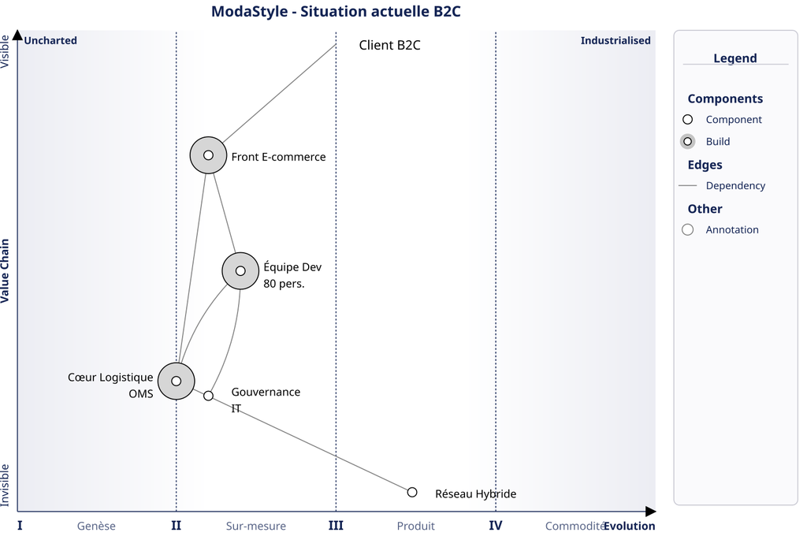

Ce que la carte montre :

Le **Cœur Logistique** est en zone Sur-mesure (c’est l’avantage concurrentiel). L’**interface de commerce électronique** l’est aussi, ce qui se discute. Mais surtout, on voit apparaître un composant souvent invisible dans les analyses de coûts : la **Gouvernance IT**.

Cette gouvernance (responsables produit, chefs de produit, architectes, comités de décision) représente 15 à 20% du budget IT. C’est le prix à payer pour coordonner 80 personnes travaillant sur une base de code unique et sur-mesure. À cette échelle, le coût est acceptable. Le système fonctionne.

Mais que se passe-t-il quand la direction demande d’ajouter le B2B ?

### 2. L’ajout du B2B : l’explosion des coûts de coordination

Le directeur commercial veut attaquer le marché B2B (comités d’entreprise, uniformes). Ce nouveau canal doit s’appuyer sur le même Cœur Logistique (c’est là que réside l’avantage). Mais l’interface actuelle n’est pas conçue pour le B2B : il faut gérer des comptes entreprise, des prix par volume, des flux de travail (*workflows*) de validation, une facturation différente.

La tentation naturelle : adapter l’interface existante. Après tout, c’est « juste » quelques fonctionnalités en plus.

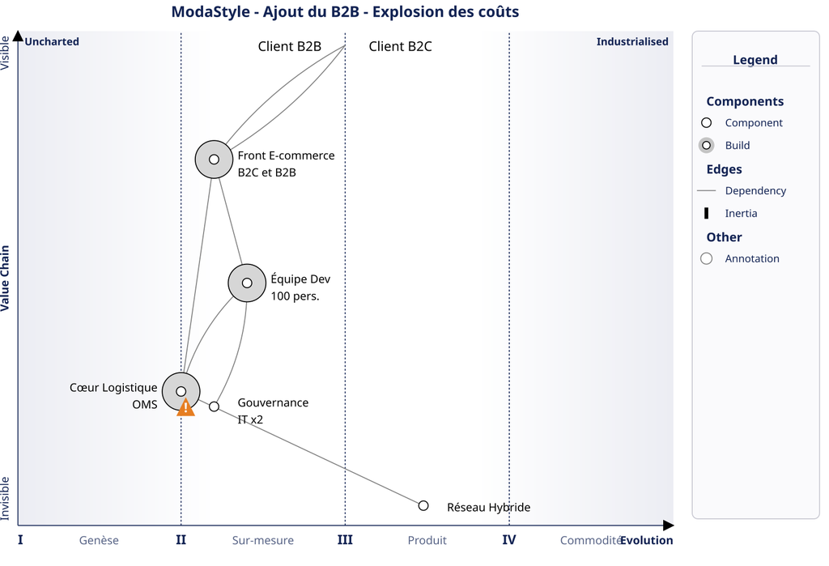

Ce que l’analyse des flux révèle :

L’équipe passe de 80 à 100 personnes (+25%). Mais la **Gouvernance** ne croît pas de 25% — elle **double**.

Pourquoi ? Parce que gérer deux métiers (B2C et B2B) dans une seule base de code crée des conflits permanents. Les priorités B2C et B2B s’affrontent en comité produit. Les architectes doivent arbitrer des choix techniques contradictoires. Les responsables produit passent leur temps à négocier des compromis. Chaque livraison devient un exercice de coordination complexe.

Le coût marginal du B2B n’est pas « le coût de 20 développeurs ». C’est le coût de 20 développeurs **plus** le coût de la complexité organisationnelle pour faire cohabiter deux métiers dans un même système.

### 3. Le dilemme : deux chemins possibles

Face à cette escalade, deux stratégies émergent.

**Option A : Productiser l’interface**

Si le système de gestion des commandes reste un avantage concurrentiel durable, il peut être pertinent de transformer l’interface en un **produit interne**, une base technique réutilisable sur laquelle on branche des déclinaisons légères (B2C, B2B, demain Location ou Seconde Vie). Chaque déclinaison a son équipe, sa feuille de route (*roadmap*), ses priorités. La coordination se fait via des API internes, pas via des réunions.

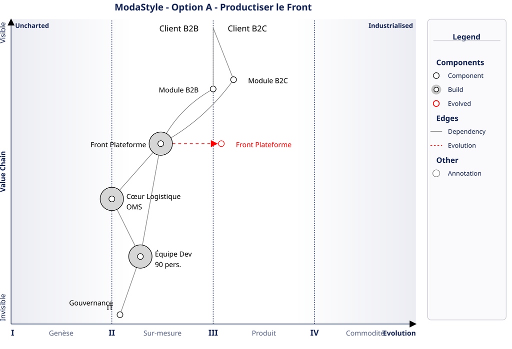

Cette option implique un investissement initial élevé pour restructurer l’interface en plateforme (*refactoring*). L’équipe reste conséquente (90 personnes) mais mieux structurée. Les nouveaux canaux deviennent des modules indépendants, l’avantage du système de gestion des commandes est préservé et exploité, et la gouvernance reste maîtrisée car les équipes sont découplées.

**Option B : Commoditiser l’interface**

Si l’avantage réside uniquement dans le système de gestion des commandes, pourquoi maintenir une interface sur-mesure ? On peut acheter des solutions du marché (Shopify pour B2C, portail en logiciel en tant que service pour B2B) et les connecter au système de gestion des commandes via API.

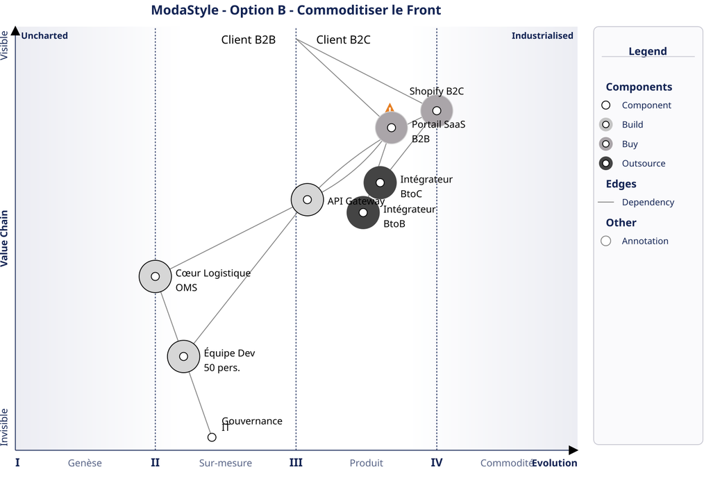

Cette option implique un coût de migration et d’intégration pour créer la passerelle API (*API Gateway*). L’équipe se réduit de 80 à 50 personnes, recentrée sur le système de gestion des commandes. La gouvernance s’allège (moins de coordination, plus d’intégration), au prix d’une dépendance aux éditeurs (Shopify, logiciel en tant que service B2B). En contrepartie, le délai de mise sur le marché (*time-to-market*) pour les nouveaux canaux devient très rapide.

### Synthèse : ce que la carte révèle

| Critère | Situation actuelle | Ajout B2B (même base) | Option A (Productiser) | Option B (Commoditiser) |
| --- | --- | --- | --- | --- |
| **Équipe** | 80 pers. | 100 pers. | 90 pers. | 50 pers. |
| **Gouvernance** | Standard | x2 (explosion) | Maîtrisée | Allégée |
| **Coût marginal nouveau canal** | N/A | Très élevé | Modéré | Faible |
| **Contrôle** | Total | Total | Total | Partiel |

La leçon stratégique :

Le sur-mesure a un coût caché : la **gouvernance**. Ce coût est acceptable quand l’équipe travaille sur un périmètre cohérent. Mais dès qu’on veut faire cohabiter deux métiers différents (B2C et B2B) dans une même base de code, les coûts de coordination explosent de manière non-linéaire.

La carte ne dit pas quelle option choisir. Elle révèle que le vrai coût du B2B n’est pas « 20 développeurs de plus » — c’est la complexité organisationnelle qui en découle. Cette prise de conscience change la nature de la décision.

Au **chapitre 10**, nous verrons comment exécuter ces manœuvres : le schéma Strangler Fig (*pattern* Strangler Fig) pour migrer progressivement, l’abstraction par API pour préserver les options, et l’alignement des équipes sur les nouvelles priorités.

## Les problèmes de doctrine révélés par la carte

Au chapitre 3, nous avons présenté les doctrines universelles de Simon Wardley (ces principes de bonne gestion qui s’appliquent quelle que soit la stratégie choisie). Une carte bien lue révèle souvent des **violations doctrinales**.

### Le syndrome NIH (Not Invented Here)

Le premier symptôme doctrinal apparaît quand des composants restent bloqués en phase Sur-mesure alors qu’ils devraient avoir glissé vers la Commodité. Vous reconstruisez ce qui existe déjà sur le marché, par fierté technique ou méfiance envers les solutions externes. C’est le syndrome du « Not Invented Here » (la croyance que ce qui n’est pas créé en interne est forcément inférieur). Cette violation trahit l’absence de deux doctrines fondamentales : « Use appropriate methods » (utiliser les bonnes méthodes) et « Challenge assumptions » (remettre en question les présupposés).

### L’absence de différenciation

À l’inverse, certaines cartes révèlent un problème tout aussi grave : tous les composants sont à droite, en zone Commodité. Aucun investissement à gauche, aucune innovation en Genèse ou Sur-mesure. Vous ne faites que consommer des commodités sans créer de valeur distinctive. Ce schéma signale un risque stratégique majeur : sans avantage concurrentiel durable, vous devenez interchangeable. Vos concurrents qui innovent vous remplaceront dès qu’ils auront atteint un niveau de maturité suffisant.

### La dispersion

Une troisième violation doctrinale se manifeste par une carte où les investissements sont répartis uniformément sur toutes les phases. Vous essayez de tout faire, partout, en même temps (innover ici, maintenir là, optimiser ailleurs). Cette dispersion trahit l’absence de priorisation stratégique. L’énergie se dissipe sans créer d’avantage significatif. Une stratégie efficace concentre les ressources là où elles créent le plus de valeur.

### Le biais de la méthode unique

Enfin, le biais de la méthode unique apparaît quand tous les composants, quelle que soit leur phase, sont gérés avec la même approche. « Ici, tout est en Scrum (cadre de gestion de projet agile) » (y compris les composants en phase Commodité qui nécessiteraient Six Sigma pour optimiser les coûts). Ou inversement : des processus rigides Six Sigma appliqués à des projets en Genèse, paralysant toute innovation. Cette uniformité crée des frictions : les composants en Commodité souffrent de rituels Agile quotidiens qui alourdissent la bureaucratie, tandis que les composants en Genèse étouffent sous des processus d’assurance qualité prématurés. Le remède consiste à créer une « boîte à outils méthodologique » et à enseigner aux équipes à choisir la méthode selon le contexte (voir Cynefin au chapitre 2).

## Alignement organisation/carte

Une dernière lecture essentielle : la carte révèle-t-elle une cohérence entre la structure de votre organisation et la nature de vos composants ?

### Vérifier l’adéquation équipe/phase

Chaque phase d’évolution appelle un type de gestion différent :

| Phase | Type d’équipe adapté | Type d’équipe inadapté |
| --- | --- | --- |
| **Genèse** | Explorateurs, créatifs, tolérants à l’échec | Optimiseurs, orientés processus |
| **Sur-mesure** | Artisans experts, ingénieurs seniors | Généralistes, juniors seuls |
| **Produit** | Chefs de produit, équipes fonctionnalités | Chercheurs, équipes R&D |
| **Commodité** | Ops, SRE (*Site Reliability Engineering*, ingénierie de fiabilité), optimiseurs de coût | Innovateurs frustrés |

Pour chaque composant de votre carte, posez-vous la question : l’équipe responsable correspond-elle à la phase du composant ? Ce simple diagnostic révèle souvent des inadéquations critiques.

### Les tensions révélées

Des tensions prévisibles apparaissent quand l’alignement est rompu. Mettez une équipe d’innovateurs sur un composant en Commodité, et vous observerez de la frustration, de la sur-ingénierie, et des coûts excessifs (ces talents veulent créer, pas maintenir). À l’inverse, confiez un composant en Genèse à une équipe habituée aux opérations, et vous verrez la paralysie s’installer : aversion au risque, processus prématurés, mort de l’innovation. Enfin, demander à un responsable unique de piloter des équipes sur plusieurs phases crée une incohérence managériale : les messages deviennent contradictoires, car ce qui fonctionne en Genèse (tolérance à l’échec) tue la performance en Commodité (excellence opérationnelle).

## Grille d’analyse pratique

Voici les questions à vous poser face à votre carte :

### Questions sur le mouvement

Quels composants de votre carte vont glisser vers la droite dans les 12 à 18 prochains mois ? La réponse n’est jamais certaine, mais il existe des signaux qui ne trompent pas. Quand plusieurs concurrents proposent soudainement des solutions similaires, quand les prix chutent de 30 % par an ou plus[^10], quand la documentation et les formations se multiplient en ligne, quand des standards ouverts commencent à émerger, alors vous assistez à une commoditisation en marche.

Prenez l’exemple des grands modèles de langage (LLM, *Large Language Models*) entre 2023 et 2024. OpenAI, Anthropic, Google, Mistral se sont lancés dans une course féroce. En 18 mois, les prix ont été divisés par dix (de GPT-3, modèle *Davinci*, à GPT-3.5 Turbo, le coût d’utilisation a été divisé par dix dès mars 2023)[^11]. Les tutoriels et cours en ligne ont explosé. Et surtout, les acteurs ont structuré leurs API pour être compatibles nativement avec le format d’OpenAI (endpoint standardisé `v1/chat/completions`), transformant l’API d’OpenAI en commodité d’interface[^12]. Résultat : les LLM sont passés de la phase Produit à la phase Commodité émergente en un temps record[^13]. Si vous aviez misé votre stratégie sur la différenciation via un LLM propriétaire en 2023, vous vous êtes probablement fait dépasser.

Autre signal : le logiciel libre (open source). Quand des projets de logiciel libre matures émergent dans un domaine, quand les géants technologiques proposent des solutions clé-en-main, quand la régulation impose des standards, la commoditisation s’accélère brutalement. Les bases de données relationnelles en sont l’illustration parfaite. Entre 2010 et 2020, MySQL et PostgreSQL sont devenus tellement robustes que les entreprises ont cessé de justifier les licences Oracle. AWS RDS (2009), Google Cloud SQL (2011) et Azure SQL Database (2010) ont automatisé l’exploitation jusqu’au bout[^14]. Le résultat ? Oracle et Microsoft ont dû adapter drastiquement leurs modèles commerciaux, passant de la vente de licences rigides à des modèles cloud (PaaS) beaucoup plus flexibles pour rester compétitifs. La bataille était perdue. Les BDD relationnelles sont devenues une commodité.

Mais le mouvement n’est pas toujours vers la droite. Parfois, une nouvelle technologie apparaît à gauche et menace de tout rebattre. Comment la détecter ? Observez les signaux faibles : des start-ups qui lèvent des fonds massifs sur un nouveau paradigme, des conférences qui consacrent soudainement des sessions entières à un sujet émergent, vos meilleurs ingénieurs qui expérimentent en projet personnel, un acteur établi qui annonce un pivot stratégique inattendu.

L’histoire des conteneurs (*containers*) est exemplaire. En 2014, Docker publiait sa version 1.0. En 2018, Kubernetes était devenu incontournable[^15]. Entre les deux, tous les signaux se sont allumés : KubeCon est passé de 500 participants en 2015 à 8 000 en 2018[^16], les ingénieurs DevOps ont massivement expérimenté (les étoiles GitHub du dépôt Docker sont passées de 5 000 à plus de 40 000 en deux ans)[^17], et Google, Microsoft, Amazon ont lancé des services managés (GKE en 2015, AKS en octobre 2017, EKS mi-2018)[^18]. Les entreprises qui avaient massivement investi dans les VMs se sont retrouvées avec une dette technique énorme. Les conteneurs avaient remplacé les VMs dans de nombreux cas d’usage.

### Questions sur l’inertie

- Quels composants sont « bloqués » alors qu’ils devraient migrer ?
- Où sont les chaînes de dépendances qui verrouillent le mouvement ?
- Quel est le coût (direct, opportunité, stratégique) de cette inertie ?

### Questions sur les flux

- L’argent circule-t-il efficacement dans la chaîne de valeur ?
- Les données sont-elles collectées et exploitées ?
- Y a-t-il des goulots d’étranglement ou des fuites de valeur ?

### Questions sur la doctrine

- Reconstruisons-nous des commodités (syndrome NIH) ?
- Investissons-nous dans la différenciation (composants à gauche) ?
- Utilisons-nous les bonnes méthodes pour chaque phase ?

### Questions sur l’alignement

- Les équipes correspondent-elles aux phases des composants ?
- Les tensions organisationnelles reflètent-elles un mauvais alignement ?
- La structure de l’organisation freine-t-elle ou accélère-t-elle le mouvement ?

### Exercice : Analysez vos flux de valeur

Reprenez une carte que vous avez créée au chapitre 8. Pour chaque lien de dépendance, posez-vous ces questions : quel type de valeur circule ? Quel est le volume ? Recevez-vous autant que vous donnez ? Un composant concentre-t-il tous les flux, créant un goulot d’étranglement ?

Les réponses révèlent souvent plus d’opportunités stratégiques que la carte elle-même.

## Conclusion : de la lecture à l’action

Mais lire ne suffit pas. Un médecin qui ne sait que diagnostiquer est un médecin incomplet. Vient le moment d’intervenir — de passer de l’observation à l’action stratégique.

C’est l’objet du chapitre suivant. Nous y explorerons les **Manœuvres stratégiques** : l’ensemble des actions délibérées que vous pouvez choisir d’exécuter pour modifier votre position sur la carte. Comment orchestrer un écosystème à votre avantage. Comment accélérer ou ralentir l’évolution d’un composant. Comment aligner vos talents sur les phases de vos composants. Comment utiliser la carte pour évaluer une acquisition ou planifier une migration.

Le diagnostic est posé. Il est temps d’apprendre à jouer.

[^1]: Nassim Nicholas Taleb, *The Black Swan: The Impact of the Highly Improbable*, Random House, 2007.
[^2]: *The Sunday Times*, « The 12 most influential books of the post-war era », article de John Carey, 19 juillet 2009.
[^3]: Nassim Nicholas Taleb, *Antifragile: Things That Gain from Disorder*, Random House, 2012.
[^4]: Pour une perspective complémentaire sur les systèmes complexes et leurs dynamiques imprévisibles, voir Donella H. Meadows, *Thinking in Systems: A Primer*, Chelsea Green Publishing, 2008.
[^5]: Méthode d’amélioration continue visant à réduire la variabilité des processus, développée par Motorola dans les années 1980.
[^6]: Directive (UE) 2022/2555 du Parlement européen et du Conseil du 14 décembre 2022, notamment l’Article 21 sur les mesures de gestion des risques en matière de cybersécurité.
[^7]: Règlement (UE) 2023/2854 (dit *Data Act*), publié le 13 décembre 2023. Le Chapitre VI est dédié à la facilitation du changement de fournisseur de services de traitement de données (effectif en septembre 2025).
[^8]: Doctrine gouvernementale « Cloud au centre » (Circulaire n° 6282/SG du 5 juillet 2021, actualisée par la circulaire n° 6400/SG en mai 2023), imposant le recours aux offres qualifiées SecNumCloud (référentiel ANSSI, version 3.2 de 2022) pour l’hébergement des données sensibles de l’État.
[^9]: Simon Wardley, *Wardley Maps*, disponible en ligne sur medium.com/@swardley.
[^10]: En analyse stratégique, une baisse soutenue des prix de l’ordre de 30 % par an sur un composant technologique (phénomène souvent modélisé par la loi de Wright et la loi de Moore appliquée au cloud) est le signal empirique majeur qu’un produit est en train de se transformer en commodité standardisée.
[^11]: Blog officiel d’OpenAI, *« Introducing ChatGPT and Whisper APIs »*, 1er mars 2023 : le coût de l’API GPT-3.5 Turbo (0,002 $/1K tokens) est annoncé comme dix fois moins cher que les modèles GPT-3 précédents.
[^12]: Plusieurs acteurs concurrents (Mistral AI, Groq, vLLM) ont adopté ce format, faisant de l’API d’OpenAI un standard de fait pour l’industrie.
[^13]: Voir l’analyse de Sequoia Capital, *« Generative AI’s Act Two »*, septembre 2023, et les rapports d’Andreessen Horowitz (a16z) documentant la standardisation rapide et l’effondrement des marges sur la couche des modèles fondationnels.
[^14]: Amazon RDS a été lancé en octobre 2009 ; Microsoft a lancé SQL Azure (devenu Azure SQL Database) en 2010 ; Google Cloud SQL a été introduit en 2011 (disponibilité générale en 2014).
[^15]: Docker 1.0 : juin 2014. Kubernetes 1.0 (Google) : juillet 2015. Dès 2018, Kubernetes a définitivement remporté la « guerre des orchestrateurs » face à Docker Swarm, devenant le standard hébergé par la CNCF.
[^16]: Rapport annuel 2018 de la CNCF (*Cloud Native Computing Foundation*). La première KubeCon (San Francisco, novembre 2015) comptait environ 500 participants ; l’édition de Seattle (décembre 2018) a réuni 8 000 personnes.
[^17]: Dépôt officiel *moby/moby* sur GitHub : environ 4 000 à 5 000 étoiles début 2014, plus de 40 000 fin 2016.
[^18]: GKE (Google) : disponibilité générale en 2015. AKS (Microsoft) : octobre 2017. EKS (Amazon) : annoncé en novembre 2017, rendu public mi-2018.

v2.16.0-beta